# pymongo_analysis

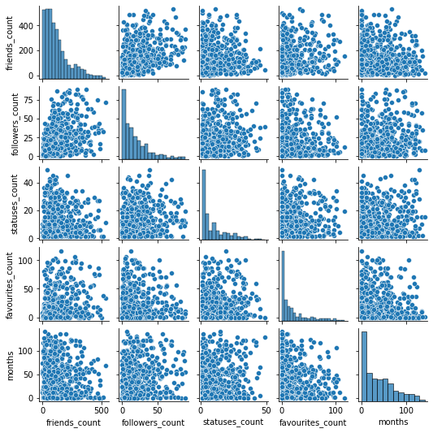

```python
sns.pairplot(gm_1[cols], height=1.5);
```

The first two cluster represent two types of inactive users, and those are users who have used twitter for a while judging by their activity, and users who didn't use twitter as much. These two cluster could be merged into a single cluster for the inactive users.

|  | friends_count | followers_count | statuses_count | favourites_count | months |
| --- | --- | --- | --- | --- | --- |
| count | 1475.000000 | 1475.000000 | 1475.000000 | 1475.000000 | 1475.000000 |
| mean | 344.890169 | 82.985763 | 58.640000 | 99.830508 | 40.489492 |
| std | 442.783955 | 115.985269 | 80.821116 | 157.576149 | 36.843527 |
| min | 0.000000 | 0.000000 | 1.000000 | 0.000000 | 0.000000 |
| 25% | 76.000000 | 11.000000 | 4.500000 | 5.000000 | 8.000000 |
| 50% | 168.000000 | 34.000000 | 21.000000 | 27.000000 | 32.000000 |
| 75% | 414.000000 | 104.000000 | 81.000000 | 117.000000 | 62.000000 |
| max | 2763.000000 | 657.000000 | 426.000000 | 859.000000 | 149.000000 |

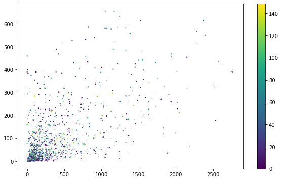

```python
inactive_users = pd.concat([gm_0, gm_1])
scatter_cluster(inactive_users, 100)
inactive_users[cols].describe()
```

Looking into the single variable distributions of this group be can see.

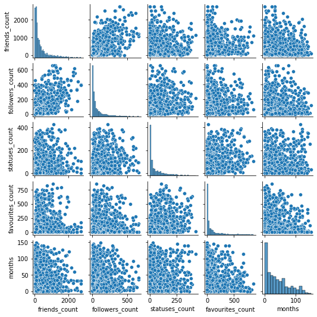

```python
import seaborn as sns

sns.pairplot(inactive_users[cols], height=1.5);
```

The distribution of months present for inactive users in right skewed, indicating that the majority of them have recently joined twitter.

|  | friends_count | followers_count | statuses_count | favourites_count | months |
| --- | --- | --- | --- | --- | --- |
| count | 59.000000 | 59.000000 | 59.000000 | 59.000000 | 59.000000 |
| mean | 1079.661017 | 21654.118644 | 174150.101695 | 41743.457627 | 114.779661 |
| std | 1284.036021 | 18199.270774 | 101895.977614 | 36929.755327 | 15.810372 |
| min | 6.000000 | 632.000000 | 8860.000000 | 110.000000 | 75.000000 |
| 25% | 336.500000 | 4847.000000 | 118271.500000 | 11185.500000 | 104.000000 |
| 50% | 712.000000 | 18621.000000 | 160685.000000 | 37384.000000 | 116.000000 |
| 75% | 1157.000000 | 32106.500000 | 220589.000000 | 58244.000000 | 124.000000 |
| max | 7439.000000 | 66838.000000 | 472219.000000 | 140197.000000 | 155.000000 |

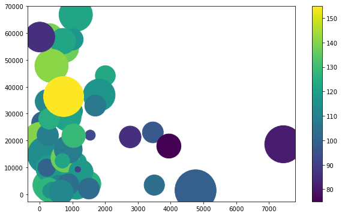

```python
scatter_cluster(gm_2, 100)
gm_2[cols].describe()
```

This cluster represents influencer users that have been on twitter for an average of 9.5 years.

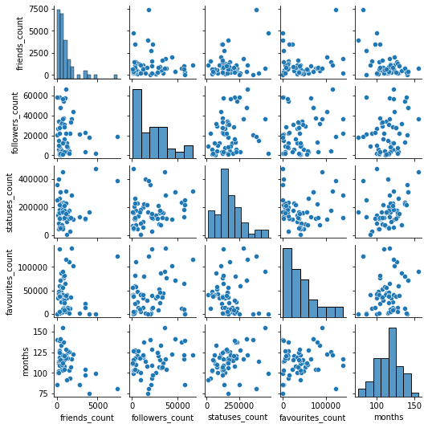

```python
sns.pairplot(gm_2[cols], height=1.5);
```

The distribution of months present appears to be normal, and centered around 116 months. The minimum months present in this cluster is 75, which indicates that this clusters contains only veteran users.

TODO: look into followers distribution more closely.

There looks to be an obvious positive correlation between months and statuses count, and a negative correlation could be present between statuses and favourites count. There is also positive correlation between statuses and followers count, indicating that users with more statuses tend to have more followers in this cluster.

|  | friends_count | followers_count | statuses_count | favourites_count | months |
| --- | --- | --- | --- | --- | --- |
| count | 389.000000 | 389.000000 | 389.000000 | 389.000000 | 389.000000 |
| mean | 467.380463 | 39036.053985 | 36860.277635 | 9067.048843 | 87.858612 |
| std | 349.376882 | 41969.994361 | 39323.361513 | 10118.170317 | 38.070242 |
| min | 0.000000 | 369.000000 | 5.000000 | 0.000000 | 1.000000 |
| 25% | 187.000000 | 9786.000000 | 8827.000000 | 1282.000000 | 60.000000 |
| 50% | 432.000000 | 21531.000000 | 22709.000000 | 4921.000000 | 96.000000 |
| 75% | 673.000000 | 53110.000000 | 55464.000000 | 13878.000000 | 118.000000 |
| max | 1665.000000 | 175558.000000 | 296673.000000 | 41224.000000 | 168.000000 |

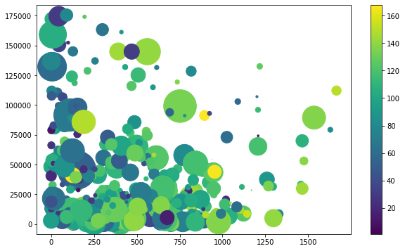

```python
scatter_cluster(gm_3, 100)
gm_3[cols].describe()
```

This cluster also represents influencer users that have been on twitter for a period less than the other group, with an average of 7 years. They also have significantly less number of average statuses.

The fading effect observed with increasing of point size indicates that spme of the users on the left might not be personal accounts, but rather official accounts.

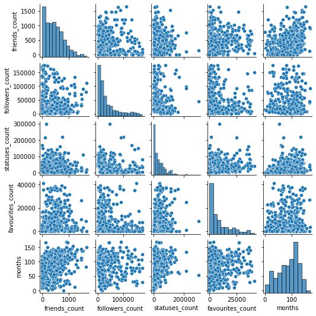

```python
sns.pairplot(gm_3[cols], height=1.5);
```

We can immediately notice in this plot that the distribution of statuses count isn't normal, and this cluster's users are generally less active than the previous cluster, or they most probably they just have joined later than the previous cluster's users. They don't exhibit the relationship between statuses count and months.

This clusters' users tend to have significantly less favourite counts than the other group.

The distribution of months present is normal with a left skew, and the minimum is 1 month, which indicates that this cluster includes users whose accounts were maybe deleted so they made new accounts, offical accounts representing entities, or anomalous users who may have gained a huge following in a short amount of time for some reason.

|  | friends_count | followers_count | statuses_count | favourites_count | months |
| --- | --- | --- | --- | --- | --- |
| count | 575.000000 | 575.000000 | 575.000000 | 575.000000 | 575.000000 |
| mean | 2956.116522 | 3189.998261 | 10617.892174 | 18503.864348 | 59.126957 |
| std | 2169.825671 | 2618.996145 | 9583.313705 | 16426.135545 | 40.478147 |
| min | 0.000000 | 27.000000 | 9.000000 | 0.000000 | 2.000000 |
| 25% | 1338.000000 | 1087.000000 | 2898.000000 | 5219.000000 | 25.000000 |
| 50% | 2439.000000 | 2596.000000 | 7626.000000 | 14322.000000 | 50.000000 |
| 75% | 4427.000000 | 4610.000000 | 15965.000000 | 27524.000000 | 92.000000 |
| max | 9315.000000 | 12035.000000 | 48065.000000 | 80164.000000 | 166.000000 |

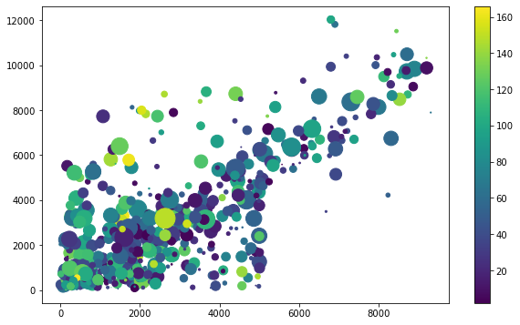

```python
scatter_cluster(gm_4, 100)
gm_4[cols].describe()
```

This is the cluster that I've been looking for, and it contains the users that have low friend to follower ratio. These users haven't been on twitter for so long, and have managed to get high follower count by using follow back schemes with other users. They tend to have less statuses than favorites count, and that maybe be because they are more observers than influencers on twitter. I would call this cluster the average joes of twitter.

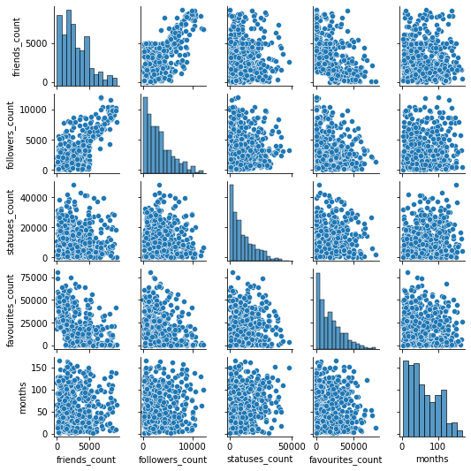

```python
sns.pairplot(gm_4[cols], height=1.5);
```

We can see that obvious linear relationship between the followers and friends count in this cluster, which wasn't present in any other cluster. We can also see the distribution of months present isn't normally distirbuted and rather right skewed, indicating that these users tend to be users who joined in the past 5 years or so.

|  | friends_count | followers_count | statuses_count | favourites_count | months |
| --- | --- | --- | --- | --- | --- |
| count | 697.000000 | 697.000000 | 697.000000 | 697.000000 | 697.000000 |
| mean | 1877.934003 | 971.296987 | 2251.068867 | 1649.187948 | 61.490674 |
| std | 1404.213064 | 710.626191 | 2068.713966 | 1742.875782 | 41.138960 |
| min | 0.000000 | 20.000000 | 1.000000 | 0.000000 | 0.000000 |
| 25% | 720.000000 | 416.000000 | 439.000000 | 233.000000 | 27.000000 |
| 50% | 1571.000000 | 847.000000 | 1641.000000 | 977.000000 | 58.000000 |
| 75% | 2818.000000 | 1353.000000 | 3819.000000 | 2548.000000 | 97.000000 |
| max | 5174.000000 | 3306.000000 | 8368.000000 | 7309.000000 | 169.000000 |

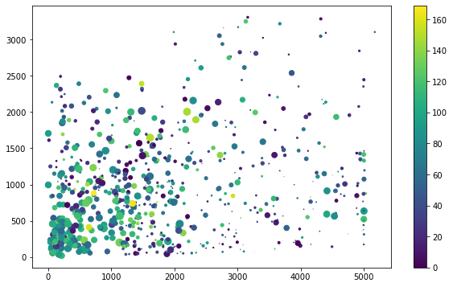

```python
scatter_cluster(gm_5, 100)
gm_5[cols].describe()
```

I think that this cluster represents another version of the average joes, and these are the less active average joes of twitter. A characterstic of this group is that they have less followers than friends on average.

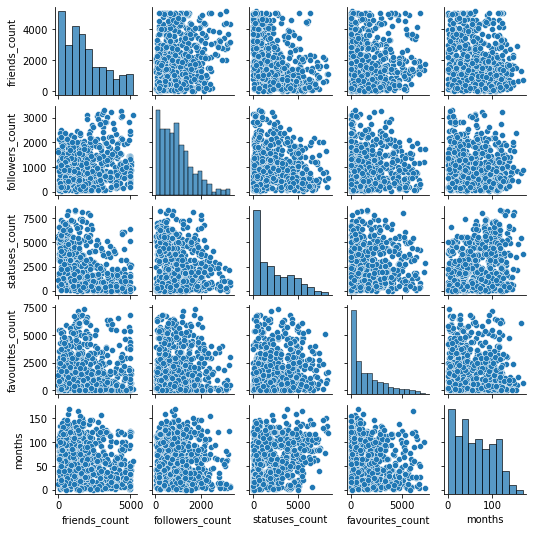

```python
sns.pairplot(gm_5[cols], height=1.5);
```

```python
# Now it's time to save these results to enable further analysis based on them
import os
import sys
import pickle as pk

from datetime import datetime


def save_model(model, filename, save_dir='models'):
    filename = '{}_{}.pkl'.format(filename, datetime.now())
    filepath = os.path.join(save_dir, filename)
    file = open(filepath+'.pkl', 'wb')

    pk.dump(model, file)
    print('Model saved as {} at {}/'.format(filename, save_dir) , file=sys.stderr)

def load_model(filename, save_dir='models'):
    filepath = os.path.join(save_dir, filename)
    file = open(filepath+'.pkl', 'rb')

    model = pk.load(file)
    print('{} loaded from {}'.format(filename, save_dir), file=sys.stderr)
```

```python
save_model(gm, 'gm')
```

```
Model saved as gm_2021-04-07 12:55:26.141024.pkl at models/
```

```python
gm__2 = load_model('gm_2021-04-07 12:55:26.141024.pkl')
```

```
gm_2021-04-07 12:55:26.141024.pkl loaded from models
```

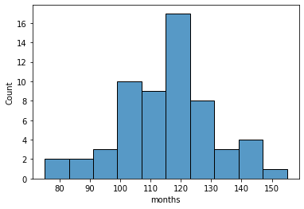

```python
# new addition

# months distribution
sns.histplot(data=gm_2.query('months > 0'), bins=10, x='months');
```

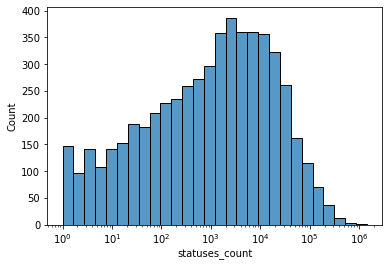

```python
# new addition

# statuses count distribution
sns.histplot(data=users_df.query('statuses_count > 0'), x='statuses_count', log_scale=True);

# statuses count distribution is log normal
```

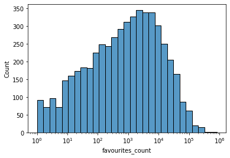

```python
# new addition

# favourite count distribution
sns.histplot(data=users_df.query('favourites_count > 0'), x='favourites_count', log_scale=True);

# the distribution of favourties is also log normal
```

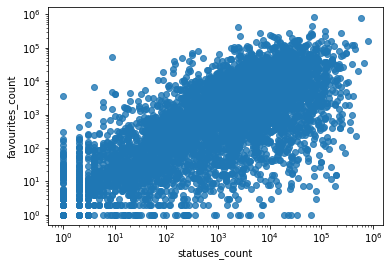

```python
# new addition

# statuses and favourites
splot = sns.regplot(data=users_df.query('favourites_count > 0'),
                    x='statuses_count',
                    y='favourites_count',
                    fit_reg=False)
splot.set(xscale='log', yscale='log');
```

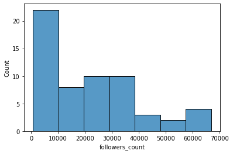

```python
# new addition

# followers distribution
sns.histplot(data=gm_2.query('followers_count > 0'), x='followers_count');

# the distribution is log normal
```

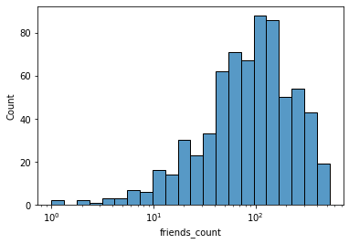

```python
# new addition

# friends distribution
sns.histplot(data=gm_1.query('friends_count > 0'), x='friends_count', log_scale=True);

# the distribution is log normal with a left skew
```

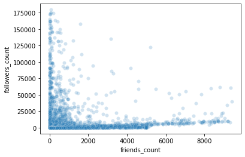

```python
# new addition

splot = sns.scatterplot(data=users_df[outliers_mask],
             x='friends_count',
             y='followers_count',
             alpha=0.2)
```